## Homework Assignment 4

#### Due Friday, February 24 at 11:59 PM CT

### Preliminaries

- Directories
  - COURSE/homework/
  - COURSE/homework/hw04/
  - COURSE/data/
  - COURSE/scripts/
- Files
  - COURSE/homework/hw04/hw04.Rmd
  - COURSE/data/ORD-2017.csv
  - COURSE/data/ORD-2018.csv
  - COURSE/data/ORD-2019.csv
  - COURSE/data/ORD-2020.csv
  - COURSE/data/ORD-2021.csv
  - COURSE/scripts/viridis.R

### Aims

- Practice data visualization using ggplot2
- Practice data wrangling with dplyr
- Practice reading in data and working with dates
- Explore additional airport waiting time data

### Problems

This assignment involves five data sets involving international flights arriving to Chicago’s O’Hare airport from January 1, 2017 through December 31, 2021 with one separate file for each year. Each file has been cleaned from the original HTML.

Each data set is in a separate CSV file: `ORD-2017.csv`, `ORD-2018.csv`, `ORD-2019.csv`, `ORD-2020.csv`, `ORD-2021.csv`.

This code chunk reads in these five data sets and combines them into a single data set.

```r
ord = map_dfr(2017:2021, ~{
  return ( read_csv(str_c("../../data/ORD-", .x, ".csv")) )
})
```

1. Make the following changes to the data set `ord`.
- Add columns for:
  - *year*;
  - *month* (character valued, use month abbreviations, Jan - Dec);
  - *day* (day of the month); and
  - *wday* (day of the week, character valued, use day abbreviations, Sun - Sat).
- Reorder the variables so that these new variables all appear directly after the date column.
- Remove the `terminal` variable.
- Rename:
  - *all_total* to *passengers*;
  - *all_flights* to *flights*; and
  - *all_booths* to *booths*.
- Arrange the rows by date and hour.
- Print all columns of the first 5 rows of this modified data frame
- Print the dimensions of this modified data frame

```r
ord = ord %>%
  mutate(date = ymd(date),
         year = year(date),
         month = as.character(month(date, label=TRUE)),
         day = day(date),
         wday = as.character(wday(date, label=TRUE))) %>%
  relocate(airport, date, year, month, day, wday) %>%
  select(-terminal) %>%
  rename(passengers = all_total, flights = all_flights, booths = all_booths) %>%
  arrange(date, hour)

ord %>% print(n=5, c=everything())
```

```
## # A tibble: 31,344 × 24
##   airport date        year month   day wday  hour        us_av…¹ us_ma…² non_u…³
##   <chr>   <date>     <dbl> <chr> <int> <chr> <chr>         <dbl>   <dbl>   <dbl>
## 1 ORD     2017-01-01  2017 Jan       1 Sun   0700 - 0800       7      24      12
## 2 ORD     2017-01-01  2017 Jan       1 Sun   0800 - 0900       5      25      13
## 3 ORD     2017-01-01  2017 Jan       1 Sun   0900 - 1000       5      37      32
## 4 ORD     2017-01-01  2017 Jan       1 Sun   1000 - 1100       8      20       8
## 5 ORD     2017-01-01  2017 Jan       1 Sun   1100 - 1200      30      89      40
## # … with 31,339 more rows, 14 more variables: non_us_max_wait <dbl>,
## #   all_avg_wait <dbl>, all_max_wait <dbl>, all_n_0_15 <dbl>,
## #   all_n_16_30 <dbl>, all_n_31_45 <dbl>, all_n_46_60 <dbl>, all_n_61_90 <dbl>,
## #   all_n_91_120 <dbl>, all_n_120_plus <dbl>, all_excluded <dbl>,
## #   passengers <dbl>, flights <dbl>, booths <dbl>, and abbreviated variable
## #   names ¹us_avg_wait, ²us_max_wait, ³non_us_avg_wait
```

```r
dim(ord)
```

```
## [1] 31344    24
```

2. Are there any dates in the range from January 1, 2017 through December 31, 2021 that are missing? If so, which ones?

```r
count_na = function(column) {
  return (sum(is.na(column)))
}
all_days = data.frame(Dates_all =
                    seq(ymd("2017-01-01"), ymd("2021-12-31"), by="days"))

ord_dates_na = ord %>%
  summarize(missing_dates_count = across(c(date, year, month, day, wday), count_na))
ord_dates_na
```

```
## # A tibble: 1 × 1
##   missing_dates_count$date $year $month  $day $wday
##                      <int> <int>  <int> <int> <int>
## 1                        0     0      0     0     0
```

```r
missing_dates = all_days %>%
  filter(!all_days$Dates_all %in% ord$date)
missing_dates
```

```
##    Dates_all
## 1 2018-05-08
## 2 2019-10-28
## 3 2019-10-29
## 4 2019-10-30
## 5 2020-02-08
```

> There are a few missing dates, although there are no missing values in any of the date, day, month, year and wday columns. The missing dates are 8th May 2018, 28th october 2019, 29th october 2019, 30th ocotber 2019, 8th february 2020.
3. Modify the `ord` data set by:
- Adding a variable named `time_of_day` which categorizes the `hour` variable in the following way:
  - midnight to 4am (“0000 - 0100” through “0300 - 0400”) is “overnight”
  - 4am to 8am is “early morning”
  - 8am to noon is “morning”
  - noon to 4pm is “afternoon”
  - 4pm to 8pm is “early evening”
  - 8pm to midnight is “late evening”
- After adding the `time_of_day` variable, this chunk of code will reorder the levels to match the times and not alphabetically.
  - This is useful so you get the desired order in summary tables and plots.
  - The function `fct_relevel()` is part of the **forcats** package in **tidyverse** which we will not study in depth.
  - Use this code (or something like it) in your solution.

```r
ord = ord %>%
  mutate(time_of_day = case_when(
    (hour >= "0000 - 0100" & hour <= "0300 - 0400") ~ "overnight",
    (hour >= "0400 - 0500" & hour <= "0700 - 0800") ~ "early morning",
    (hour >= "0800 - 0900" & hour <= "1100 - 1200") ~ "morning",
    (hour >= "1200 - 1300" & hour <= "1500 - 1600") ~ "afternoon",
    (hour >= "1600 - 1700" & hour <= "1900 - 2000") ~ "early evening",
    (hour >= "2000 - 2100" & hour <= "2300 - 0000") ~ "late evening"
  ))
ord = ord %>%
  mutate(time_of_day =
           fct_relevel(time_of_day,
                       c("overnight", "early morning", "morning", "afternoon", "early evening", "late evening")))
```

- Create a summary table which counts the number of rows for each `time_of_day` and `hour` combination. Verify that the top ten rows of your data set match these values.

```r
ord %>%
  group_by(time_of_day, hour) %>%
  summarize(n=n())
```

```
## # A tibble: 24 × 3
## # Groups:   time_of_day [6]
##    time_of_day   hour            n
##    <fct>         <chr>       <int>
##  1 overnight     0000 - 0100  1345
##  2 overnight     0100 - 0200   538
##  3 overnight     0200 - 0300   167
##  4 overnight     0300 - 0400   125
##  5 early morning 0400 - 0500   520
##  6 early morning 0500 - 0600  1024
##  7 early morning 0600 - 0700  1355
##  8 early morning 0700 - 0800  1286
##  9 morning       0800 - 0900  1434
## 10 morning       0900 - 1000  1447
## # … with 14 more rows
```

```
   time_of_day   hour            n
   <fct>         <chr>       <int>
 1 overnight     0000 - 0100  1345
 2 overnight     0100 - 0200   538
 3 overnight     0200 - 0300   167
 4 overnight     0300 - 0400   125
 5 early morning 0400 - 0500   520
 6 early morning 0500 - 0600  1024
 7 early morning 0600 - 0700  1355
 8 early morning 0700 - 0800  1286
 9 morning       0800 - 0900  1434
10 morning       0900 - 1000  1447
```

- Create an additional summary table which calculates the total number of flights which arrive during each of these time periods. This table will have six rows.
- Print the table.

```r
total_flights = ord %>%
  group_by(time_of_day) %>%
  summarize(total_flights = sum(flights))

total_flights
```

```
## # A tibble: 6 × 2
##   time_of_day   total_flights
##   <fct>                 <dbl>
## 1 overnight              3456
## 2 early morning          6073
## 3 morning               14293
## 4 afternoon             44029
## 5 early evening         38545
## 6 late evening          10171
```

4. Use a bar graph to display the total number of flights in each time period as calculated in the previous problem. There should be six categories of time period from “overnight” to “late evening”. Add a title and meaningful axis labels.

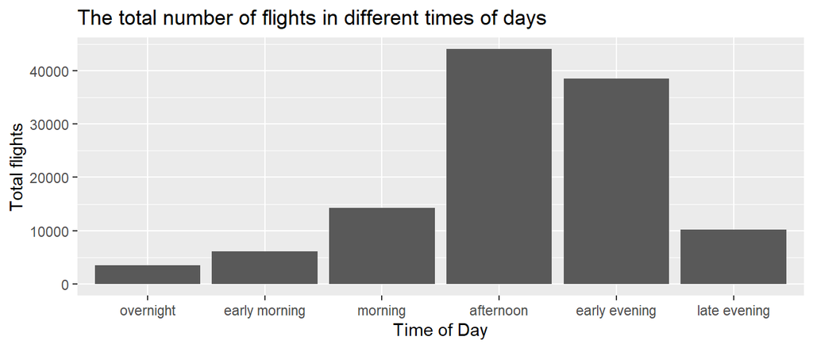

```r
ggplot(total_flights, aes(x=time_of_day, y=total_flights)) +
  geom_col() +
  xlab("Time of Day") +
  ylab("Total flights") +
  ggtitle("The total number of flights in different times of days")
```

5. Create a data summary table with the average daily number of passengers by month and year.
- Display this data summary with a bar chart where month is on the x-axis and average daily passenger counts are on the y axis
- Add meaningful axis labels and a title to this graph.
- Change the y axis scale labels so values are regular numbers with commas. *(Use `scale_y_continuous()` as below)*
- Display the graph with a different facet for each year

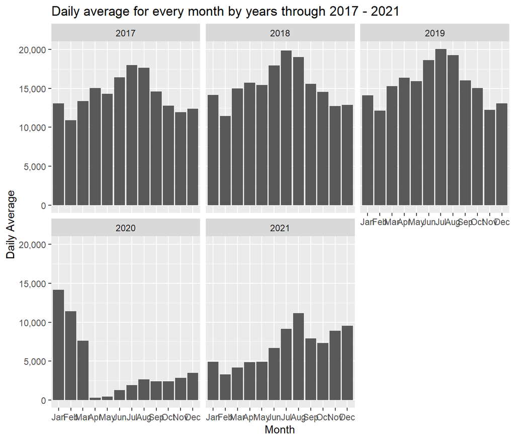

```r
prob5 = ord %>%
  group_by(day, month, year) %>%
  summarize(daily_total = sum(passengers))

## data summary
prob5 = prob5 %>%
  group_by(month, year) %>%
  summarize(days = n(), total_month = sum(daily_total), average = total_month / days) %>%
  arrange(month)

## plot the table
ggplot(prob5, aes(y=average, x=factor(month, levels =c("Jan", "Feb", "Mar", "Apr", "May", "Jun", "Jul", "Aug", "Sep", "Oct", "Nov", "Dec")))) +
  geom_col() +
  facet_wrap(vars(year)) +
  scale_y_continuous(label = scales::comma) +
    xlab("Month") +
    ylab("Daily Average") +
  ggtitle("Daily average for every month by years through 2017 - 2021")
```

6. What striking feature is apparent in this graph? What explains this feature of the data?

> One of the most striking features apparent in this graph would be the sudden dip through the months of January, February and March and the steep drop of daily average of passengers in the month of April and very gradual increase thereafter for the year of 2020. The average has very slowly increased hereafter. This may be explained by the fact that that is around the time when COVID-19 had struck the world and numerous restrictions on air travel were levied all around the world along with lockdowns. This drastically reduced the number of flights and the passengers being carried. Interestingly, the average still hasn’t reached the pre-COVID era averages.
7. Investigate the average number of passengers per day of the week for the years 2017–2019.
- For each day of the week (Sunday – Saturday), calculate the average number of arriving daily passengers to ORD on international flights. Display this table sorted from highest to lowest average. *(Hint: you need to total passengers by date and day of week before taking averages.)*
- Print the entire table

```r
prob6 = ord %>%
  filter(year>=2017 & year<=2019) %>%
  group_by(date, wday) %>%
  summarize(total = sum(passengers)) %>%
  group_by(wday) %>%
  summarize(n=n(), total = sum(total), average = total/n) %>%
  arrange(desc(average))

prob6
```

```
## # A tibble: 7 × 4
##   wday      n   total average
##   <chr> <int>   <dbl>   <dbl>
## 1 Sat     156 2804113  17975.
## 2 Sun     157 2609996  16624.
## 3 Mon     156 2352517  15080.
## 4 Fri     156 2348997  15058.
## 5 Wed     155 2154440  13900.
## 6 Thu     156 2123433  13612.
## 7 Tue     155 2080826  13425.
```

8. Identify the 20 dates with the highest total number of arriving passengers. How many of these dates are the day of the week identified in the previous problem with the highest average?

```r
highest_dates = ord %>%
  group_by(date) %>%
  summarize(total = sum(passengers)) %>%
  arrange(desc(total)) %>%
  head(20)

highest_dates %>%
  mutate(date = ymd(date), weekday = wday(date, label=TRUE))
```

```
## # A tibble: 20 × 3
##    date       total weekday
##    <date>     <dbl> <ord>
##  1 2018-01-04 24119 Thu
##  2 2018-08-04 22648 Sat
##  3 2018-07-07 22573 Sat
##  4 2019-08-10 22460 Sat
##  5 2018-06-30 22414 Sat
##  6 2019-07-06 22370 Sat
##  7 2019-08-03 22334 Sat
##  8 2018-08-11 22326 Sat
##  9 2019-06-29 22297 Sat
## 10 2018-07-14 22296 Sat
## 11 2018-07-28 22247 Sat
## 12 2019-07-27 22171 Sat
## 13 2018-08-18 22011 Sat
## 14 2018-07-21 21973 Sat
## 15 2019-08-17 21830 Sat
## 16 2019-07-13 21776 Sat
## 17 2019-07-20 21773 Sat
## 18 2019-06-22 21641 Sat
## 19 2018-01-06 21605 Sat
## 20 2018-06-23 21590 Sat
```

> Of the 20 dates with the highest total number of arriving passengers, 19 are Saturdays, that is the weekday with the highest average of arriving passengers for the years 2017 - 2019. It is interesting to note that the highest total of arriving passengers on a single day was recorded on a Thursday which on average has the second lowest average of arriving passengers through 2017 to 2019.